# Lab 2 Decision Trees

KMG

November 12, 2019

## Load libraries and data

```r
library(rpart)
library(rattle)
library(caret)
library(caTools)
library(ROCR)
```

```r
library(rpart.plot)
library(ipred)
library(randomForest)
library(dplyr)
library(forcats)

glass_with_id = read.csv("glass.csv", head=FALSE, sep = ",")
glass_with_id$V11 = factor(glass_with_id$V11, levels = c(1,2,3,5,6,7),
                           labels=c("building_windows_float_processed",
                                    "building_windows_non_float_processed",
                                    "vehicle_windows_float_processed",
                                    "containers",
                                    "tableware",
                                    "headlamps"))
#Takes TARGET column/varaible and changes to a factor and then applies names
glass = glass_with_id[ -c(1) ] #takes out id column (1st column)
View(glass)
dim(glass)
```

```
## [1] 214  10
```

```r
summary(glass)
```

```
##        V2              V3              V4              V5
##  Min.   :1.511   Min.   :10.73   Min.   :0.000   Min.   :0.290
##  1st Qu.:1.517   1st Qu.:12.91   1st Qu.:2.115   1st Qu.:1.190
##  Median :1.518   Median :13.30   Median :3.480   Median :1.360
##  Mean   :1.518   Mean   :13.41   Mean   :2.685   Mean   :1.445
##  3rd Qu.:1.519   3rd Qu.:13.82   3rd Qu.:3.600   3rd Qu.:1.630
##  Max.   :1.534   Max.   :17.38   Max.   :4.490   Max.   :3.500
##        V6              V7               V8               V9
##  Min.   :69.81   Min.   :0.0000   Min.   : 5.430   Min.   :0.000
##  1st Qu.:72.28   1st Qu.:0.1225   1st Qu.: 8.240   1st Qu.:0.000
##  Median :72.79   Median :0.5550   Median : 8.600   Median :0.000
##  Mean   :72.65   Mean   :0.4971   Mean   : 8.957   Mean   :0.175
##  3rd Qu.:73.09   3rd Qu.:0.6100   3rd Qu.: 9.172   3rd Qu.:0.000
##  Max.   :75.41   Max.   :6.2100   Max.   :16.190   Max.   :3.150
##       V10                                            V11
##  Min.   :0.00000   building_windows_float_processed    :70
##  1st Qu.:0.00000   building_windows_non_float_processed:76
##  Median :0.00000   vehicle_windows_float_processed     :17
##  Mean   :0.05701   containers                          :13
##  3rd Qu.:0.10000   tableware                           : 9
##  Max.   :0.51000   headlamps                           :29
```

## Split the data into two sets: train(80%) and test(20%)

```r
set.seed(123)
split = sample.split(glass$V11, SplitRatio = 0.8)
train = subset(glass, split==TRUE)
test = subset(glass, split==FALSE)
test_no_class = subset(glass, select=-V11, split==FALSE)
```

## Pull out only the class/target variable from the test dataset

```r
class = test$V11
```

## Build a basic regression tree using the train function and using the best complexity paramter (cp) number

```r
fitcontrol = trainControl(method = "cv", number = 10)
#set up cross validation
grid_cp = expand.grid(cp=seq(0, 0.05, 0.005))
#find best complexity parameter

mod = train(V11 ~ ., data=train, method = "rpart",
            trControl=fitcontrol, metric="Accuracy",
            maximize=TRUE, tuneGrid=grid_cp)
mod
```

```
## CART
##
## 171 samples
##   9 predictor
##   6 classes: 'building_windows_float_processed', 'building_windows_non_float_processed', 'vehicle_windows_float_processed', 'containers', 'tableware', 'headlamps'
##
## No pre-processing
## Resampling: Cross-Validated (10 fold)
## Summary of sample sizes: 154, 155, 155, 154, 153, 154, ...
## Resampling results across tuning parameters:
##
##   cp     Accuracy   Kappa
##   0.000  0.7073164  0.5974474
##   0.005  0.7073164  0.5974474
##   0.010  0.7135664  0.6059580
##   0.015  0.7191219  0.6134580
##   0.020  0.7191219  0.6128815
##   0.025  0.7132396  0.6024716
##   0.030  0.7132396  0.5996028
##   0.035  0.7069896  0.5888916
##   0.040  0.6954764  0.5735841
##   0.045  0.6849501  0.5590270
##   0.050  0.6845825  0.5581062
##
## Accuracy was used to select the optimal model using the largest value.
## The final value used for the model was cp = 0.02.
```

```r
#best cp = 0.02
```

## Test the best cp model of cp = 0.02

```r
pred_reg = predict(mod, test_no_class)
```

## Confusion matrix to see how well our cp = 0.02 model performed

```r
confusionMatrix(pred_reg, class)
```

```
## Confusion Matrix and Statistics
##
##                                       Reference
## Prediction                             building_windows_float_processed
##   building_windows_float_processed                                   11
##   building_windows_non_float_processed                                3
##   vehicle_windows_float_processed                                     0
##   containers                                                          0
##   tableware                                                           0
##   headlamps                                                           0
##                                       Reference
## Prediction                             building_windows_non_float_processed
##   building_windows_float_processed                                        2
##   building_windows_non_float_processed                                   10
##   vehicle_windows_float_processed                                         1
##   containers                                                              1
##   tableware                                                               0
##   headlamps                                                               1
##                                       Reference
## Prediction                             vehicle_windows_float_processed
##   building_windows_float_processed                                   1
##   building_windows_non_float_processed                               1
##   vehicle_windows_float_processed                                    1
##   containers                                                         0
##   tableware                                                          0
##   headlamps                                                          0
##                                       Reference
## Prediction                             containers tableware headlamps
##   building_windows_float_processed              0         0         0
##   building_windows_non_float_processed          1         1         1
##   vehicle_windows_float_processed               0         0         1
##   containers                                    2         1         0
##   tableware                                     0         0         0
##   headlamps                                     0         0         4
##
## Overall Statistics
##
##                Accuracy : 0.6512
##                  95% CI : (0.4907, 0.7899)
##     No Information Rate : 0.3488
```

[output cut: 29 more lines]

```
## Pos Pred Value                                      0.33333
## Neg Pred Value                                      0.95000
## Prevalence                                          0.06977
## Detection Rate                                      0.02326
## Detection Prevalence                                0.06977
## Balanced Accuracy                                   0.64167
##                      Class: containers Class: tableware Class: headlamps
## Sensitivity                    0.66667          0.00000          0.66667
## Specificity                    0.95000          1.00000          0.97297
## Pos Pred Value                 0.50000              NaN          0.80000
## Neg Pred Value                 0.97436          0.95349          0.94737
## Prevalence                     0.06977          0.04651          0.13953
## Detection Rate                 0.04651          0.00000          0.09302
## Detection Prevalence           0.09302          0.00000          0.11628
## Balanced Accuracy              0.80833          0.50000          0.81982
```

# The accuracy is 0.6512 which is fair. This % shows how often my model is correct.

# The p-value is 5.184e-05 which is the chance that random different data could produce these same results. That chance is low here.

# The kappa statistic is moderate at 0.5212. The kappa is a measure of how closely the data points classified by my model matched the data classes in my actual data aka ground truth. It is a metric that compares an Observed Accuracy with an Expected Accuracy (random chance). The kappa controls for the accuracy of a random classifier model as measured by the expected accuracy. The kappa statistic shows how the classifier itself performed as the kappa statistic for one model is directly comparable to the kappa statistic for any other model used for the same classification task. One standard interpretation of the kappa measurement shows 0-0.20 as slight, 0.21-0.40 as fair, 0.41-0.60 as moderate, 0.61-0.80 as substantial, and 0.81-1 as almost perfect. Another standard considers kappas > 0.75 as excellent, 0.40-0.75 as fair to good, and < 0.40 as poor.

# The sensitivity is 0.7857 for building_windows_float_processed, 0.6667 for building windows_non_float_processed, 0.33333 for vehicle_windows_float_processed, 0.66667 for containers, 0.00000 for tableware, and 0.66667 for headlamps. We want this value high. It is also known as the true positive rate. This measure tells us how often the model is correct when the actual value is positive or how sensitive is my model to detecting positive instances.

# The specificity is 0.8966 for building_windows_float_processed, 0.7500 for building windows_non_float_processed, 0.95000 for vehicle_windows_float_processed, 0.95000 for containers, 1.00000 for tableware, and 0.97297 for headlamps. This measure tells us how often the model is correct when the actual value is negative or how specific is the model.

## Plot cp = 0.02 model

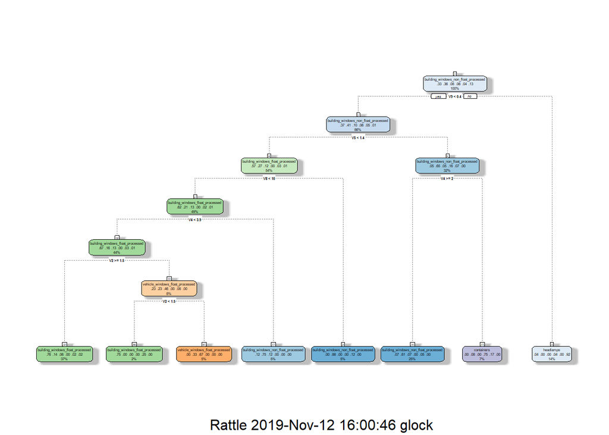

```r
control=rpart.control(xval=10, minbucket=2, minsplit=4, cp=0.02)
mod_rp = rpart(V11~ ., data=train, control=control)
fancyRpartPlot(mod_rp)
```